# Lab 09

Jerry Xing

Nov 4, 2025

### Question 1

```
[1] "n.sample = 1"
[1] "mean = -0.000866584611775253"
[1] "sd = 0.998554598718562"
```

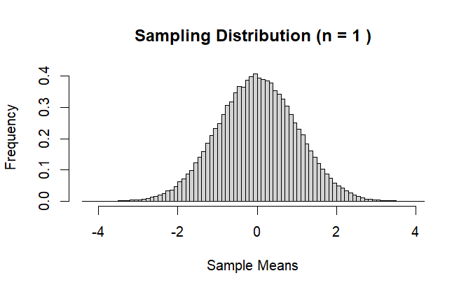

```r
NormalMeans <- function(n.sample, n.trials){
  sample.mean <- replicate(n.trials, mean(rnorm(n.sample, 0, 1)))
  grand.mean <- mean(sample.mean)
  sd <- sd(sample.mean)

  print(paste0("n.sample = ", n.sample))
  print(paste0("mean = ", grand.mean))
  print(paste0("sd = ", sd))
  hist(sample.mean,
       breaks = 100,
       probability = TRUE,
       main = paste("Sampling Distribution (n =", n.sample, ")"),
       xlab = "Sample Means",
       ylab = "Frequency")
}

NormalMeans(1,1e5)
```

```
[1] "n.sample = 2"
[1] "mean = -0.00188290836065462"
[1] "sd = 0.708478663635238"
```

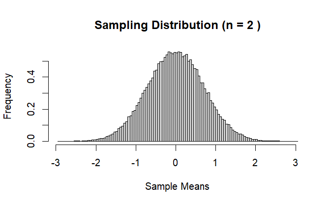

```r
NormalMeans(2,1e5)
```

```
[1] "n.sample = 10"
[1] "mean = 0.000552031820289086"
[1] "sd = 0.316843498936354"
```

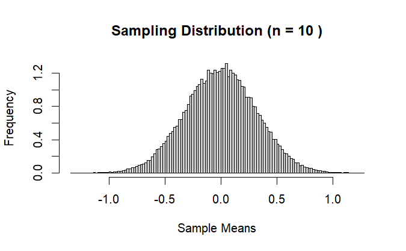

```r
NormalMeans(10,1e5)
```

```
[1] "n.sample = 50"
[1] "mean = 6.04720096722392e-05"
[1] "sd = 0.141516934883891"
```

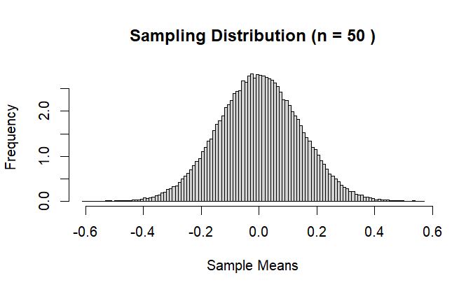

```r
NormalMeans(50,1e5)
```

```
[1] "n.sample = 100"
[1] "mean = 6.31829290873513e-06"
[1] "sd = 0.100155516830344"
```

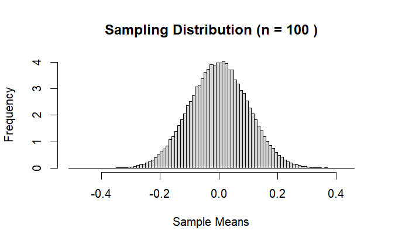

```r
NormalMeans(100,1e5)
```

When `n.sample` increase, the mean and sd gradually approach 0;

From the histogram, it can be seen that as `n.sample` increases, the distribution of the sample means becomes more concentrated, shrinking from the range of -4 to 4 to approximately -0.4 to 0.4. If they are plotted on the same coordinate axis, the graph should become narrower as the `n.sample` increases.

### Question 2

```
[1] "n.sample = 1"
[1] "mean = 1.00029988017056"
[1] "sd = 1.00048888393543"
```

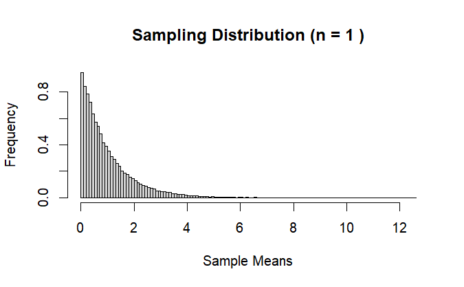

```r
ExponentialMeans <- function(n.sample, n.trials){
    sample.mean <- replicate(n.trials, mean(rexp(n.sample, 1)))
  grand.mean <- mean(sample.mean)
  sd <- sd(sample.mean)

  print(paste0("n.sample = ", n.sample))
  print(paste0("mean = ", grand.mean))
  print(paste0("sd = ", sd))
  hist(sample.mean,
       breaks = 100,
       probability = TRUE,
       main = paste("Sampling Distribution (n =", n.sample, ")"),
       xlab = "Sample Means",
       ylab = "Frequency")
}

ExponentialMeans(1,1e5)
```

```
[1] "n.sample = 2"
[1] "mean = 1.00030746441237"
[1] "sd = 0.708748939451025"
```

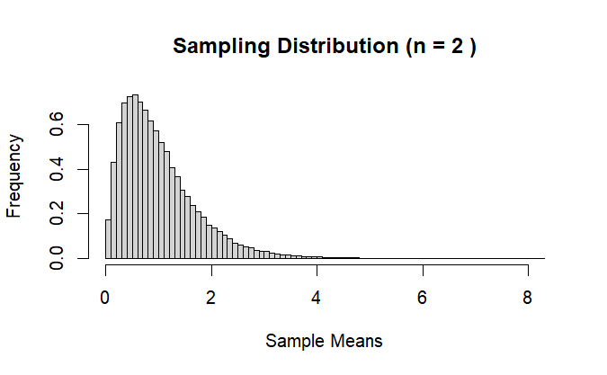

```r
ExponentialMeans(2,1e5)
```

```
[1] "n.sample = 10"
[1] "mean = 0.999483635079527"
[1] "sd = 0.317249594325926"
```

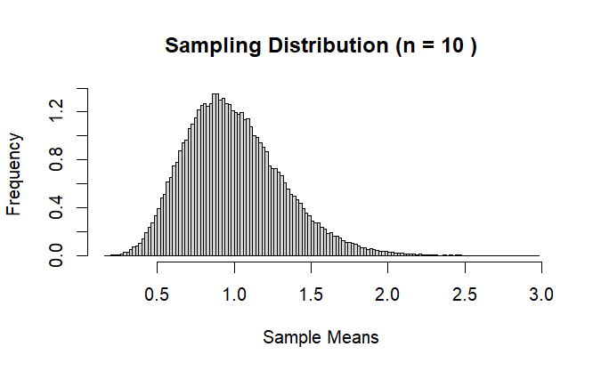

```r
ExponentialMeans(10,1e5)
```

```
[1] "n.sample = 50"
[1] "mean = 0.999889561259423"
[1] "sd = 0.14105167231224"
```

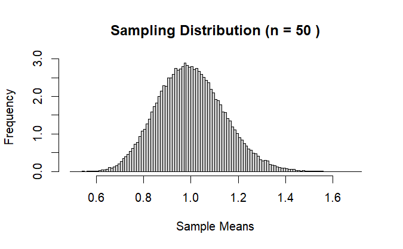

```r
ExponentialMeans(50,1e5)
```

```
[1] "n.sample = 100"
[1] "mean = 1.00005593207781"
[1] "sd = 0.100183658402492"
```

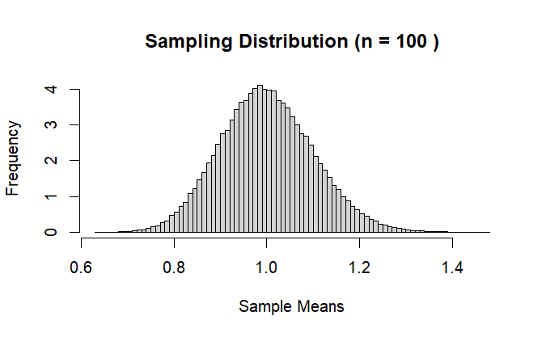

```r
ExponentialMeans(100,1e5)
```

When `n.sample` increase, the mean gradually approaches 1, and the sd gradually approaches 0.

From the histogram, it can be seen that as `n.sample` increases, the distribution of the sample means becomes more concentrated (or narrower), and its shape gradually resembles a normal distribution.

### Question 3

```r
ExponentialMeansProb <- function(n.trials, beta, n.sample, z){
  mu <- beta
  sigma <- beta

  sample.means <- replicate(n.trials, mean(rexp(n.sample, 1/beta)))

  lower.val <- mu - z * sigma/sqrt(n.sample)
  upper.val <- mu + z * sigma/sqrt(n.sample)

  result <- mean(sample.means > lower.val & sample.means < upper.val)
    print(result)
}

ExponentialMeansProb(1e5, 1, 1, 1)
ExponentialMeansProb(1e5, 1, 1, 2)
ExponentialMeansProb(1e5, 1, 1, 3)
ExponentialMeansProb(1e5, 1, 5, 1)
ExponentialMeansProb(1e5, 1, 5, 2)
ExponentialMeansProb(1e5, 1, 5, 3)
ExponentialMeansProb(1e5, 1, 50, 1)
ExponentialMeansProb(1e5, 1, 50, 2)
ExponentialMeansProb(1e5, 1, 50, 3)
```

|  | $z=1$ | $z=2$ | $z=3$ |
| --- | --- | --- | --- |
| `n.sample` $=1$ | 0.86536 | 0.95022 | 0.98208 |
| `n.sample` $=5$ | 0.70228 | 0.95956 | 0.99099 |
| `n.sample` $=50$ | 0.68454 | 0.95553 | 0.99638 |

When `n.sample` is small, the range for `z = 1` does not follow the empirical rule, while the others mostly do; as `n.sample` increases, the results align more closely with the empirical rule.

### Question 4

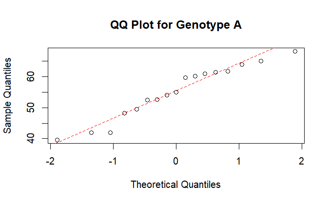

```r
library(MASS)
data("genotype")

A <- subset(genotype, Litter == "A")
B <- subset(genotype, Litter == "B")
I <- subset(genotype, Litter == "I")
J <- subset(genotype, Litter == "J")

qq.Plot <- function(set){
  qqnorm(set$Wt,
         main = paste0("QQ Plot for Genotype ",unique(set$Litter))
         )
  qqline(set$Wt, col="red", lty="dashed")
}

qq.Plot(A)
```

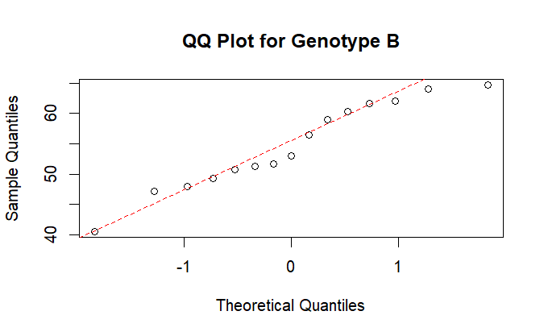

```r
qq.Plot(B)
```

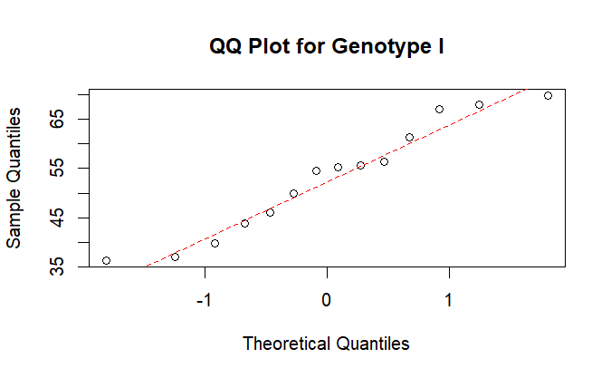

```r
qq.Plot(I)
```

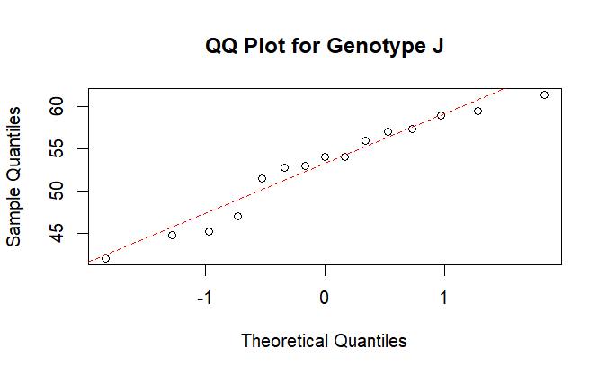

```r
qq.Plot(J)
```

They appear to follow a normal distribution because all four QQ plots are approximately linear overall. For group `I`, there may be some deviations, but it still generally lies along the straight line.